# MAS2908 - Practical 07 (Solutions)

Clement Lee

Semester 2, 2025/2026

# 1 Introduction

This practical focuses on visualising temporal (time series) data and understanding the difference between `geom_line()` and `geom_path()`. You will learn how to:

- Create line plots for time series data
- Understand the key difference between `geom_line()` and `geom_path()`
- Use `geom_path()` to visualise how two variables evolve together over time
- Handle data ordering issues in temporal visualisation

# 2 Data: Money Demand

We will use the `moneydemand` dataset from Practical 4 (available on Canvas). Recall its key variables:

- `year`: Year of observation (1879–1974)
- `Rs`: Short-term interest rate
- `Rl`: Long-term interest rate
- `Rm`: Interest rate on money
- `logSpp`: Log of stock prices

```r
moneydemand <- read_csv("moneydemand.csv"))
str(moneydemand)
```

```
## spc_tbl_ [96 × 7] (S3: spec_tbl_df/tbl_df/tbl/data.frame)
##  $ year  : num [1:96] 1879 1880 1881 1882 1883 ...
##  $ logM  : num [1:96] -7.42 -7.25 -7.09 -7.04 -7.01 ...
##  $ logYp : num [1:96] 5.61 5.7 5.74 5.79 5.81 ...
##  $ Rs    : num [1:96] 5.07 5.23 5.2 5.64 5.62 ...
##  $ Rl    : num [1:96] 4.88 4.58 4.26 4.31 4.33 4.28 4.08 3.81 3.87 3.8 ...
##  $ Rm    : num [1:96] 2.58 2.73 2.87 3.14 3.16 2.89 2.23 2.86 3.51 2.95 ...
##  $ logSpp: num [1:96] -3.76 -2.69 -2.7 -2.67 -2.79 ...
##  - attr(*, "spec")=
##   .. cols(
##   ..   year = col_double(),
##   ..   logM = col_double(),
##   ..   logYp = col_double(),
##   ..   Rs = col_double(),
##   ..   Rl = col_double(),
##   ..   Rm = col_double(),
##   ..   logSpp = col_double()
##   .. )
##  - attr(*, "problems")=<externalptr>
```

# 3 `geom_line()` vs `geom_path()`

The key difference between these two geoms:

- **`geom_line()`**: Connects points in order of the **$x$-variable**
- **`geom_path()`**: Connects points in **row order** (the order they appear in the data frame)

## 3.1 When they are the same

When data is sorted by the $x$-variable (as is typical for time series), both geoms produce identical plots:

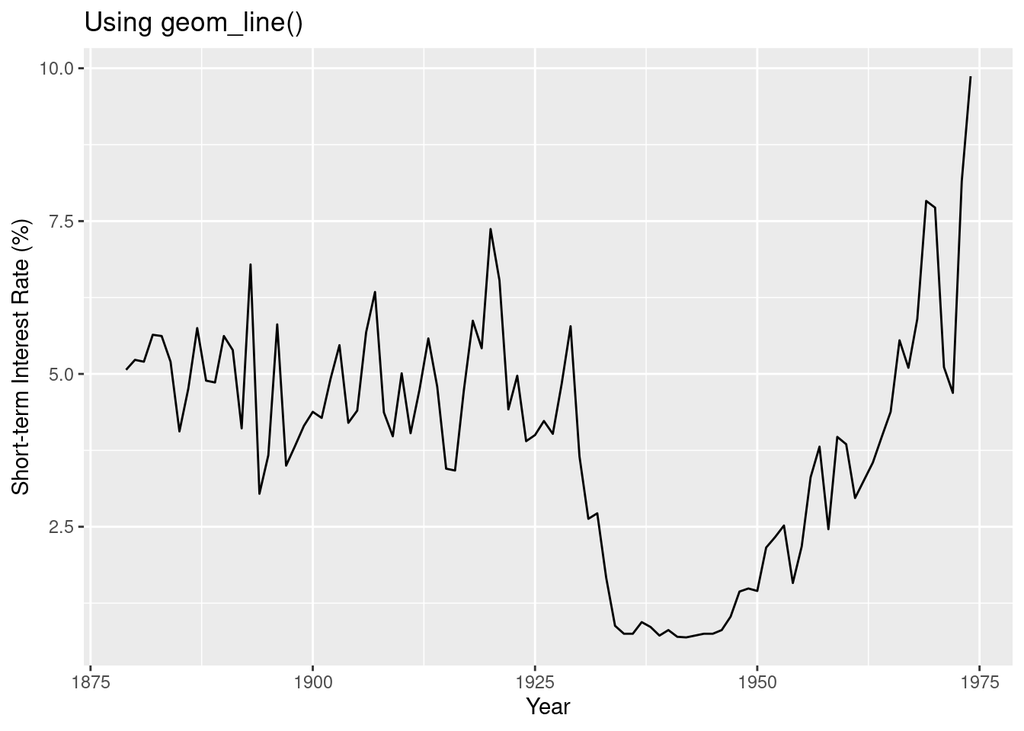

```r
# Using geom_line()
ggplot(moneydemand, aes(x = year, y = Rs)) +
  geom_line() +
  labs(x = "Year", y = "Short-term Interest Rate (%)",
       title = "Using geom_line()")
```

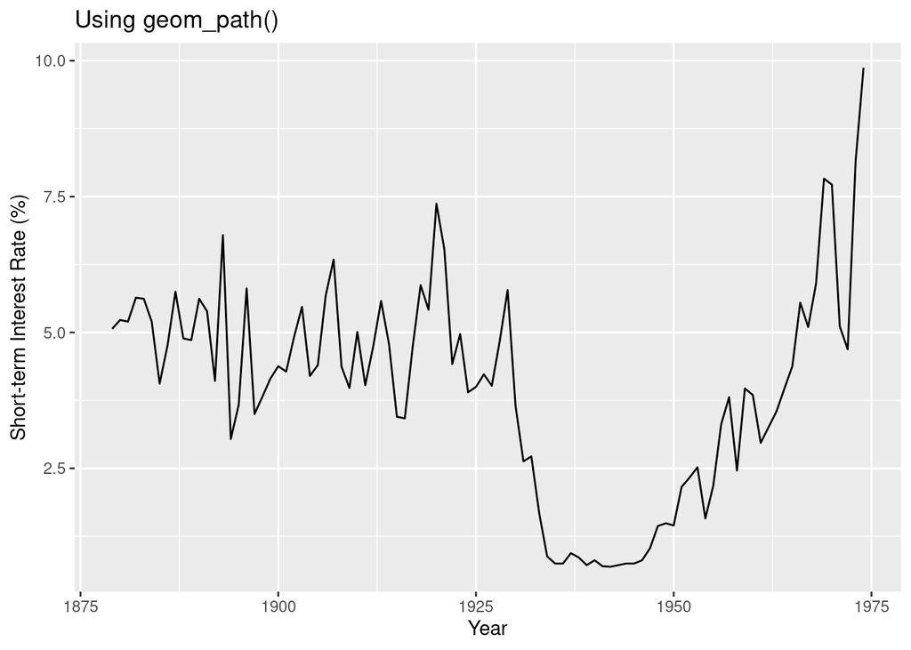

```r
# Using geom_path() - identical result
ggplot(moneydemand, aes(x = year, y = Rs)) +
  geom_path() +
  labs(x = "Year", y = "Short-term Interest Rate (%)",
       title = "Using geom_path()")
```

## 3.2 When they differ

Let’s shuffle the rows and see what happens:

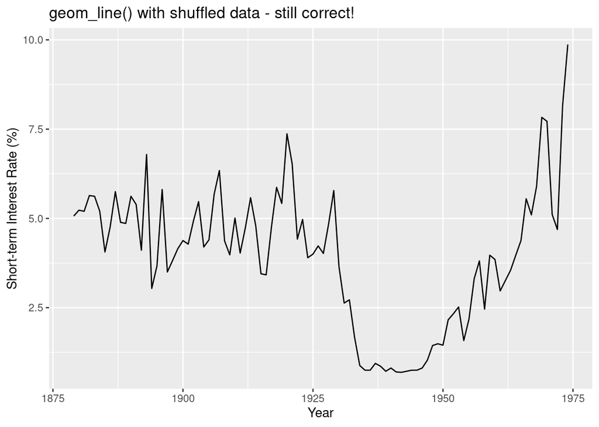

```r
set.seed(42)
moneydemand_shuffled <- moneydemand |>
  slice_sample(n = nrow(moneydemand))  # shuffle all rows

# geom_line() still works - it sorts by x internally
ggplot(moneydemand_shuffled, aes(x = year, y = Rs)) +
  geom_line() +
  labs(x = "Year", y = "Short-term Interest Rate (%)",
       title = "geom_line() with shuffled data - still correct!")
```

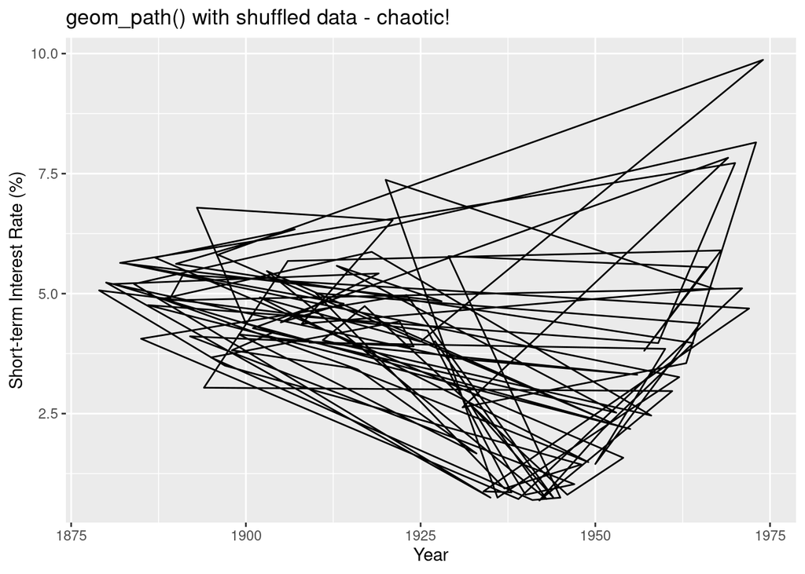

```r
# geom_path() creates chaos - it connects in row order
ggplot(moneydemand_shuffled, aes(x = year, y = Rs)) +
  geom_path() +
  labs(x = "Year", y = "Short-term Interest Rate (%)",
       title = "geom_path() with shuffled data - chaotic!")
```

## 3.3 Exercises

1. Create a line plot of `Rl` (long-term interest rate) over `year` using the original (unshuffled) `moneydemand` data. Add appropriate axis labels.

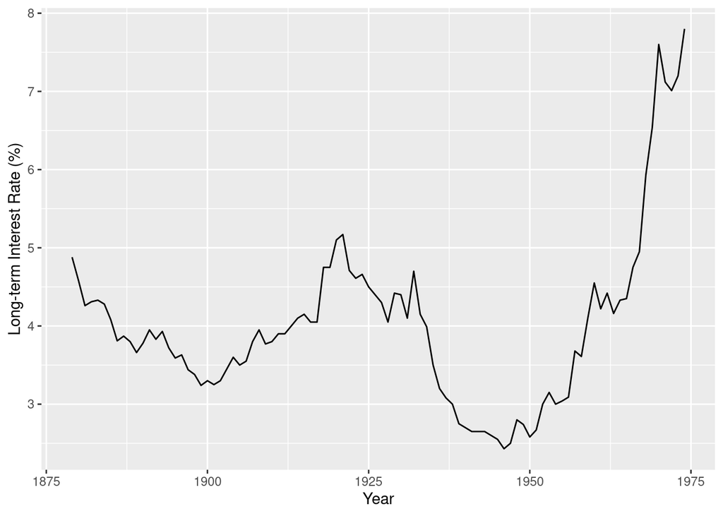

   ```r
   ggplot(moneydemand, aes(x = year, y = Rl)) +
     geom_line() +
     labs(x = "Year", y = "Long-term Interest Rate (%)")
   ```

2. Using the shuffled data `moneydemand_shuffled`, try to create the same plot using `geom_path()`. Describe what happens and explain why.

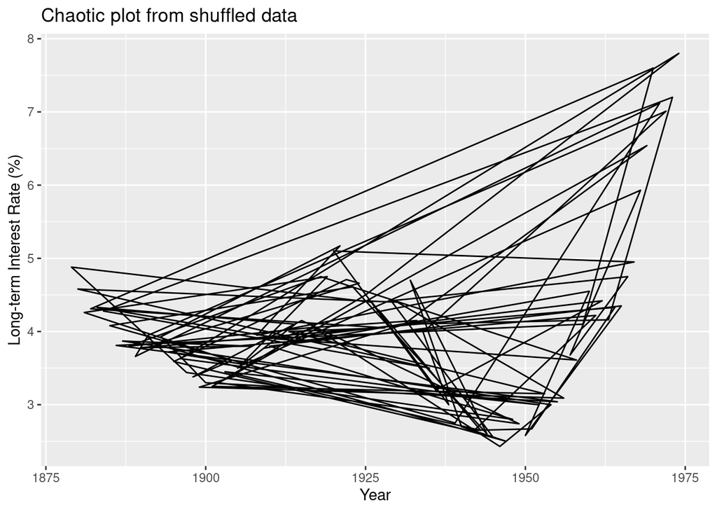

   ```r
   ggplot(moneydemand_shuffled, aes(x = year, y = Rl)) +
     geom_path() +
     labs(x = "Year", y = "Long-term Interest Rate (%)",
          title = "Chaotic plot from shuffled data")
   ```

   The plot appears chaotic because `geom_path()` connects points in row order, not by the $x$-value. Since the data is shuffled, it jumps backwards and forwards in time.
3. Fix the chaotic plot from Q2 by sorting the data before plotting. Use `arrange()` within the pipe.

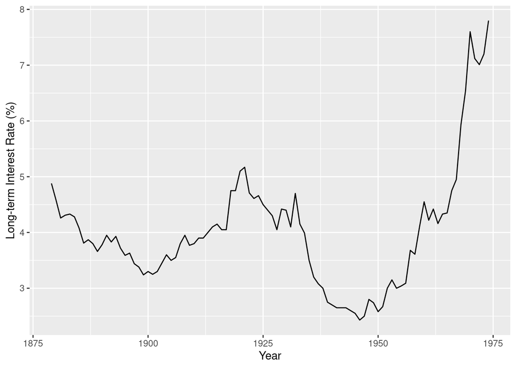

   ```r
   moneydemand_shuffled |>
     arrange(year) |>
     ggplot(aes(x = year, y = Rl)) +
     geom_path() +
     labs(x = "Year", y = "Long-term Interest Rate (%)")
   ```

4. Explain why `geom_line()` would produce a correct plot even with shuffled data, while `geom_path()` would not.

   `geom_line()` internally sorts the data by the $x$-variable before connecting points, so row order doesn’t matter. `geom_path()` connects points in the exact order they appear in the data frame, so if rows are shuffled, the connecting lines will jump around chaotically.

# 4 Using `geom_path()` to explore two variables over time

The real power of `geom_path()` is showing how **two variables evolve together over time**. By plotting one variable against another and connecting in temporal order, you add time as a third dimension.

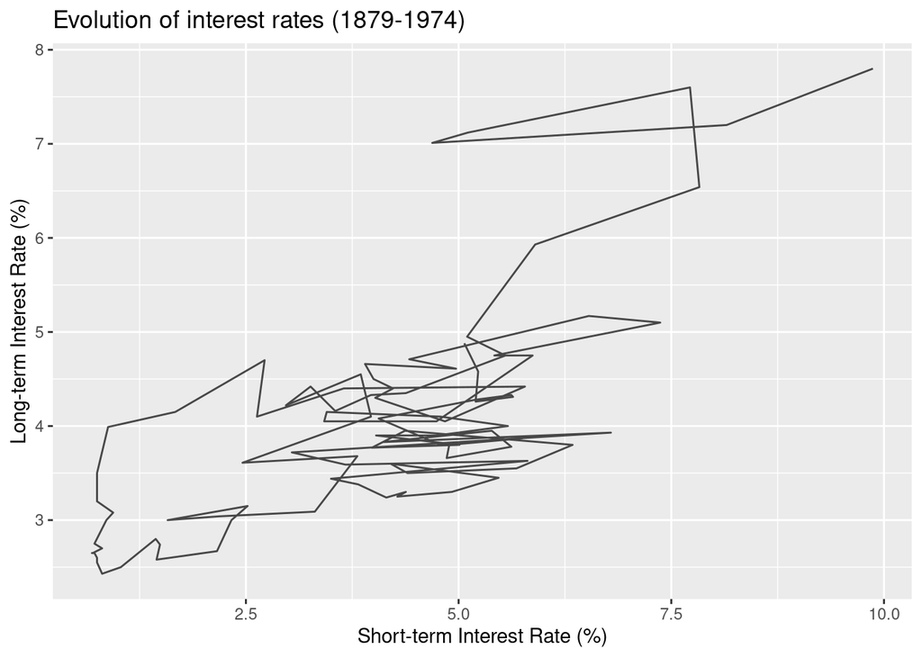

```r
ggplot(moneydemand, aes(x = Rs, y = Rl)) +
  geom_path(alpha = 0.7) +
  labs(x = "Short-term Interest Rate (%)",
       y = "Long-term Interest Rate (%)",
       title = "Evolution of interest rates (1879-1974)")
```

## 4.1 Enhancing with colour

Map `year` to colour to show the temporal progression:

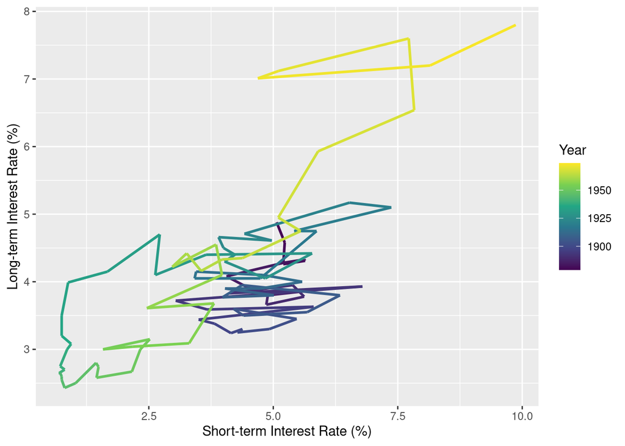

```r
ggplot(moneydemand, aes(x = Rs, y = Rl, colour = year)) +
  geom_path(linewidth = 1) +
  scale_colour_viridis_c() +
  labs(x = "Short-term Interest Rate (%)",
       y = "Long-term Interest Rate (%)",
       colour = "Year")
```

## 4.2 A polished example

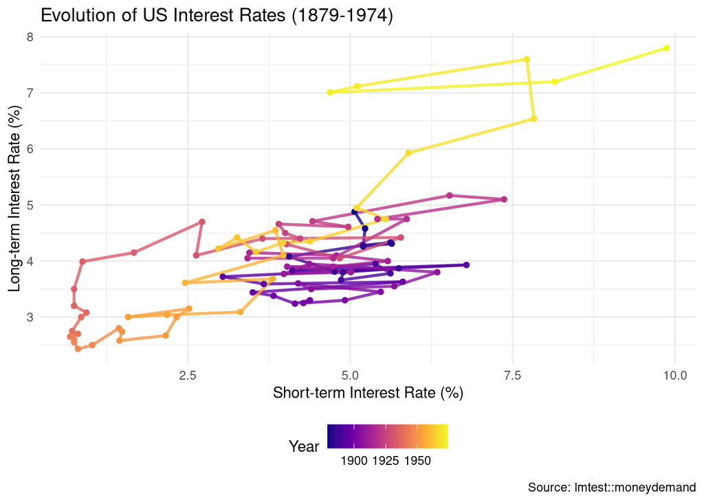

Figure 4.1: A polished time series visualisation combining multiple concepts.

```r
ggplot(moneydemand, aes(x = Rs, y = Rl, colour = year)) +
  geom_path(linewidth = 1, alpha = 0.8) +
  geom_point(size = 1.5) +
  scale_colour_viridis_c(option = "plasma") +
  labs(
    x = "Short-term Interest Rate (%)",
    y = "Long-term Interest Rate (%)",
    colour = "Year",
    title = "Evolution of US Interest Rates (1879-1974)",
    caption = "Source: lmtest::moneydemand"
  ) +
  theme_minimal() +
  theme(legend.position = "bottom")
```

## 4.3 Exercises

5. Create a `geom_path()` plot showing how `Rm` (interest rate on money) and `logSpp` (log stock prices) evolved together over time. Map `year` to colour.

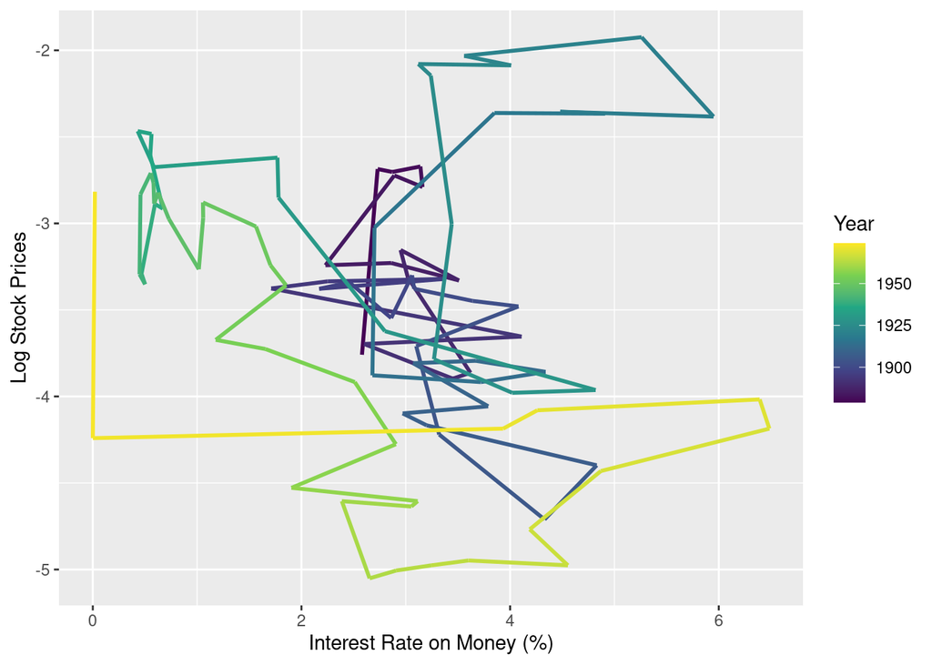

   ```r
   ggplot(moneydemand, aes(x = Rm, y = logSpp, colour = year)) +
     geom_path(linewidth = 1) +
     scale_colour_viridis_c() +
     labs(x = "Interest Rate on Money (%)",
          y = "Log Stock Prices",
          colour = "Year")
   ```

6. Create a similar plot for `Rs` (short-term rate) vs `logSpp`. Add points on top of the path to mark individual years.

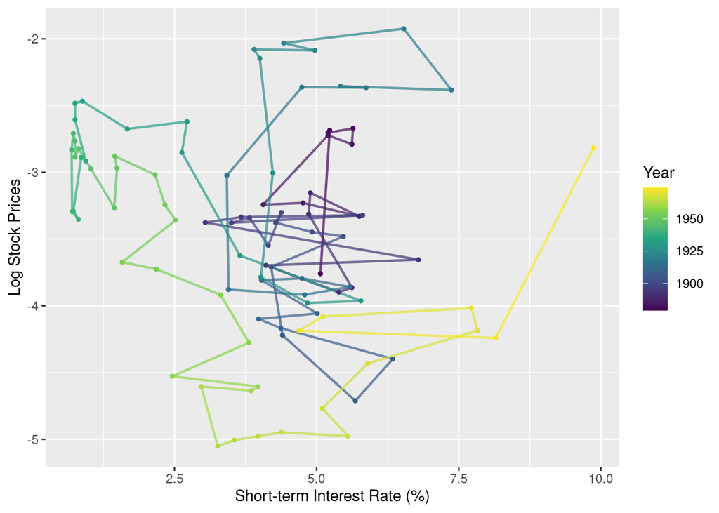

   ```r
   ggplot(moneydemand, aes(x = Rs, y = logSpp, colour = year)) +
     geom_path(linewidth = 0.8, alpha = 0.7) +
     geom_point(size = 1) +
     scale_colour_viridis_c() +
     labs(x = "Short-term Interest Rate (%)",
          y = "Log Stock Prices",
          colour = "Year")
   ```

7. Using the shuffled data, attempt to create the plot from Q5. Describe what goes wrong and how you would fix it.

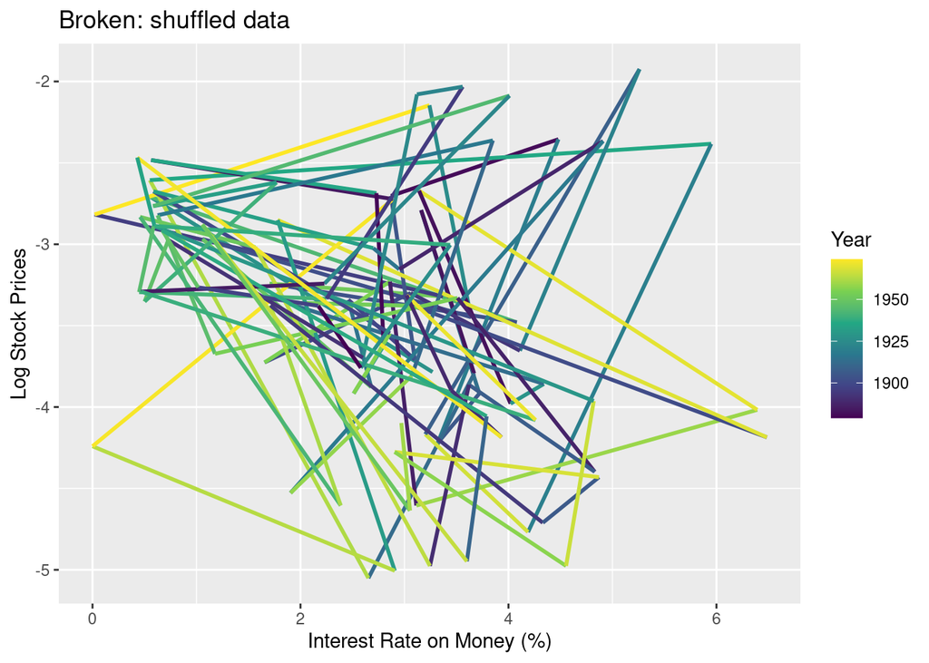

   ```r
   # Broken version with shuffled data
   ggplot(moneydemand_shuffled, aes(x = Rm, y = logSpp, colour = year)) +
     geom_path(linewidth = 1) +
     scale_colour_viridis_c() +
     labs(x = "Interest Rate on Money (%)",
          y = "Log Stock Prices",
          colour = "Year",
          title = "Broken: shuffled data")
   ```

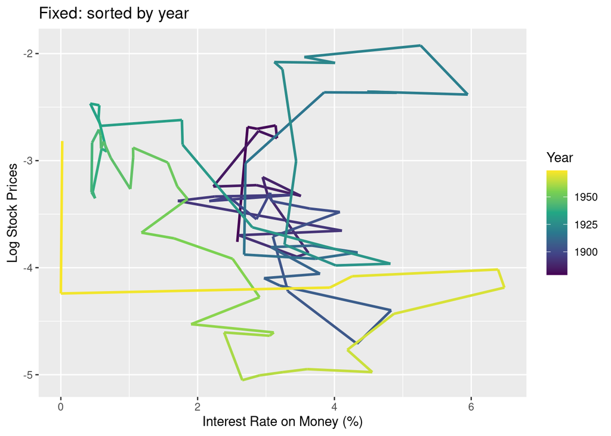

   ```r
   # Fixed by arranging by year
   moneydemand_shuffled |>
     arrange(year) |>
     ggplot(aes(x = Rm, y = logSpp, colour = year)) +
     geom_path(linewidth = 1) +
     scale_colour_viridis_c() +
     labs(x = "Interest Rate on Money (%)",
          y = "Log Stock Prices",
          colour = "Year",
          title = "Fixed: sorted by year")
   ```

   With shuffled data, `geom_path()` connects points in the wrong order, creating a chaotic criss-crossing pattern. The fix is to sort by `year` using `arrange(year)` before plotting.
8. Compare the `Rs` vs `Rl` path plot with a simple scatterplot (`geom_point()` only). What additional information does `geom_path()` reveal that the scatterplot does not?

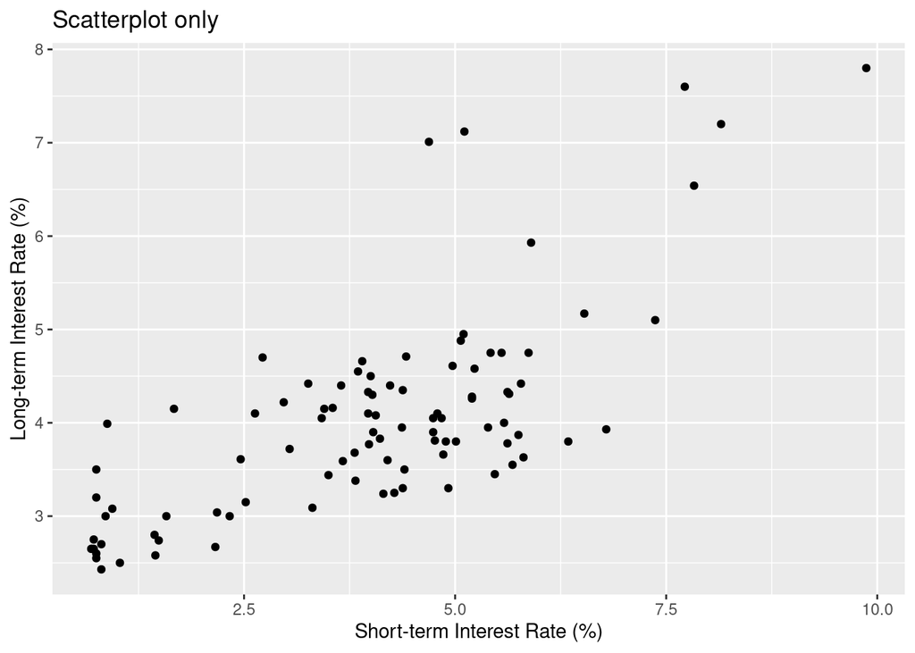

   ```r
   # Scatterplot only
   ggplot(moneydemand, aes(x = Rs, y = Rl)) +
     geom_point() +
     labs(x = "Short-term Interest Rate (%)",
          y = "Long-term Interest Rate (%)",
          title = "Scatterplot only")
   ```

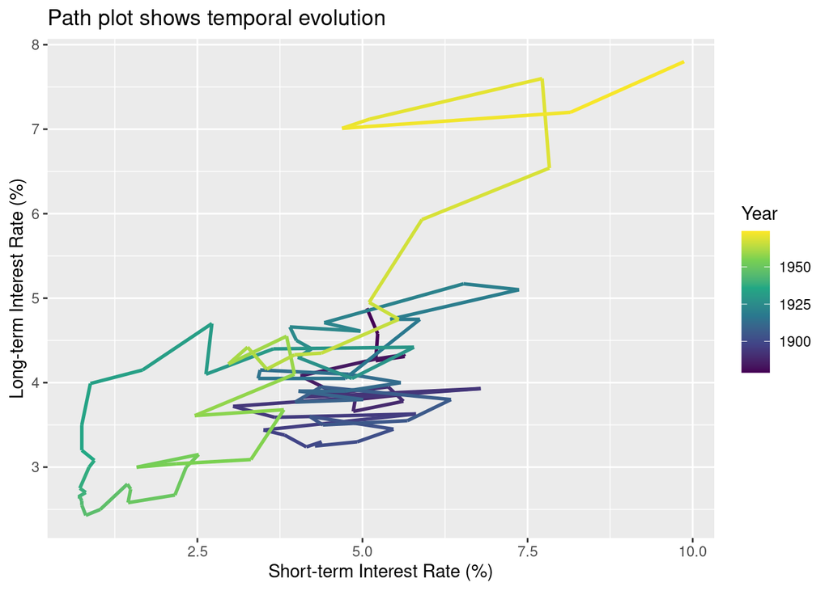

   ```r
   # Path plot
   ggplot(moneydemand, aes(x = Rs, y = Rl, colour = year)) +
     geom_path(linewidth = 1) +
     scale_colour_viridis_c() +
     labs(x = "Short-term Interest Rate (%)",
          y = "Long-term Interest Rate (%)",
          colour = "Year",
          title = "Path plot shows temporal evolution")
   ```

   The scatterplot shows the relationship between the two variables but not the temporal order. The path plot reveals how the variables evolved together over time — you can see the trajectory the economy took through this 2-D space from 1879 to 1974, including periods of rapid change and more stable periods.

# 5 Working with dates

## 5.1 `lubridate`

Real-world time series data often comes with dates stored as separate columns (year, month, day) or as strings. The `lubridate` package provides functions to assemble these into proper date or time objects that R understands:

> **Note:** R’s technical name for these objects is “datetime” (specifically `POSIXct`). We use “time object” here to avoid confusion with `Date` objects, since “datetime” contains “date” and the two can easily be mixed up.

| Function | Purpose | Example |
| --- | --- | --- |
| `make_datetime()` | Create time object from components | `make_datetime(year, month, day, hour)` |
| `make_date()` | Create date object from components | `make_date(year, month, day)` |
| `ymd()` | Parse date from a string | `ymd("2024-01-15")` |
| `year()`, `month()`, `day()` | Extract components from a date | `year(date_column)` |

```r
library(lubridate)

# Create a date column from separate year/month/day integer columns
data <- data |>
  mutate(date = make_date(year, month, day))

# Create a datetime column (if hours are also available)
data <- data |>
  mutate(datetime = make_datetime(year, month, day, hour))
```

The `moneydemand` dataset uses a single integer `year` column, so `lubridate` is not needed here. For datasets with daily or hourly observations (e.g., a column each for year, month, day), using `make_date()` or `make_datetime()` is essential for correct axis spacing and labelling.

## 5.2 Formatting date axes: `scale_x_date()` and `strftime()` format codes

Once you have a proper date column, `scale_x_date()` (for `Date` objects) or `scale_x_datetime()` (for `POSIXct` objects) lets you control how the axis labels are formatted. The `date_labels` argument accepts `strftime()` format codes:

| Code | Meaning | Example |
| --- | --- | --- |
| `%Y` | 4-digit year | 2024 |
| `%b` | Abbreviated month | Jan, Feb |
| `%B` | Full month name | January |
| `%d` | Day of month | 01–31 |

Since `moneydemand$year` is a numeric integer (not a `Date`), the simplest approach is `scale_x_continuous()` with custom `breaks`:

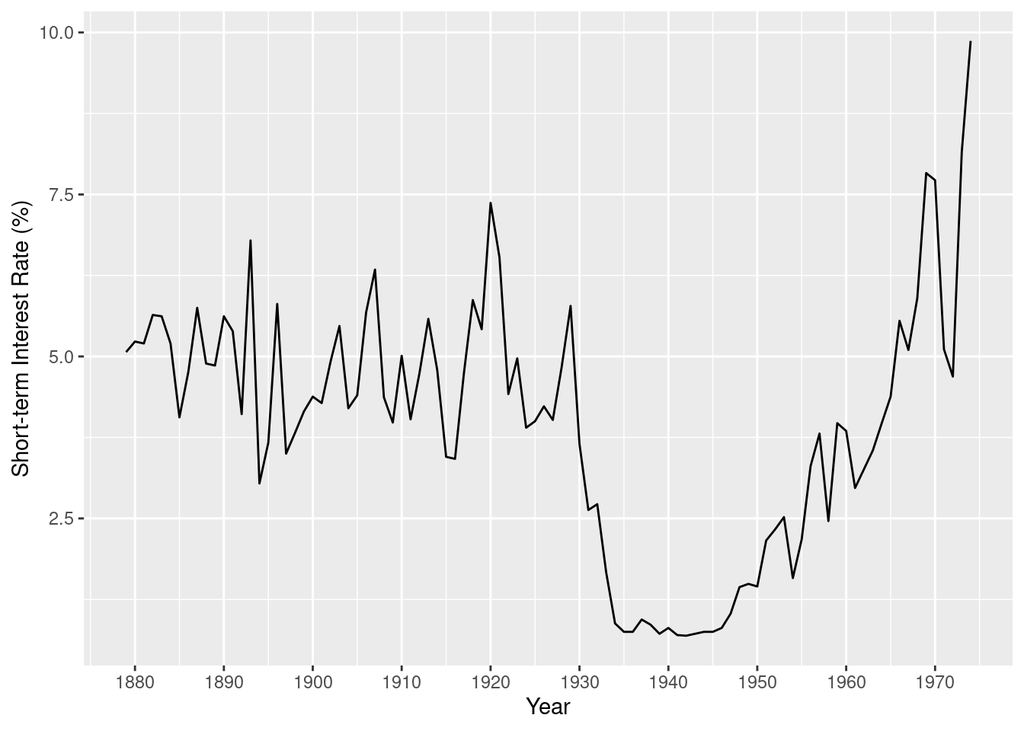

```r
ggplot(moneydemand, aes(x = year, y = Rs)) +
  geom_line() +
  scale_x_continuous(breaks = seq(1880, 1970, by = 10)) +
  labs(x = "Year", y = "Short-term Interest Rate (%)")
```

Alternatively, we can convert `year` to a proper `Date` object first using `mutate()` and `make_date()`. This unlocks `scale_x_date()`, which accepts `strftime()` format codes via its `date_labels` argument and handles date spacing automatically:

```r
library(lubridate)
```

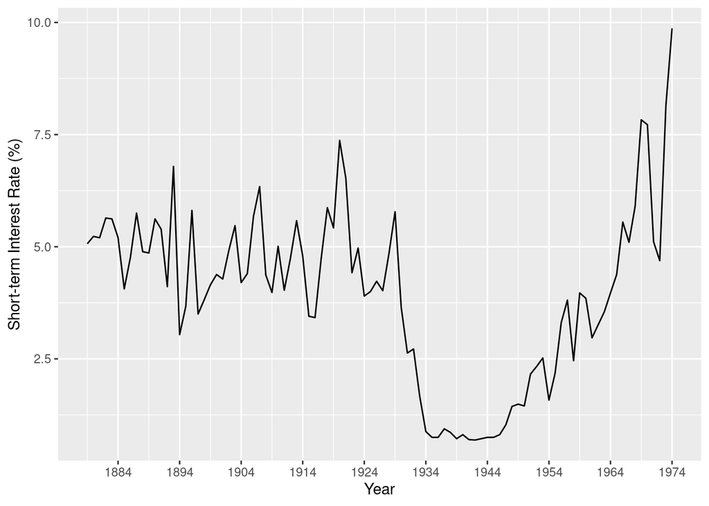

```r
moneydemand |>
  mutate(date = make_date(year)) |>
  ggplot(aes(x = date, y = Rs)) +
  geom_line() +
  scale_x_date(date_labels = "%Y",
               date_breaks = "10 years") +
  labs(x = "Year", y = "Short-term Interest Rate (%)")
```

Both plots look the same here, but the `scale_x_date()` approach generalises to datasets with monthly or daily data, where you might use `date_labels = "%b %Y"` (e.g., “Jan 1960”) or `date_labels = "%d %b"` (e.g., “15 Jan”).

# 6 Summary

**`geom_line()` vs `geom_path()`:**

- `geom_line()` connects points by $x$-value; robust to shuffled data
- `geom_path()` connects points by row order; requires sorted data
- Both produce identical results when data is sorted by $x$

**When to use which:**

- Use `geom_line()` for standard time series ($y$ vs time on $x$-axis)
- Use `geom_path()` to show how two variables evolve together over time, adding time as a third dimension

**Fixing shuffled data:**

- Sort by the time variable using `arrange()` before plotting with `geom_path()`
- Or use `geom_line()` which handles unsorted data automatically

**Working with dates:**

- For data with separate year/month/day columns, use `lubridate::make_date()` or `make_datetime()` to create proper date or time objects before plotting
- For data stored as strings, use `ymd()` (and related functions) to parse them into dates
- Once you have a `Date` column, use `scale_x_date(date_labels = ...)` to format axis labels using `strftime()` codes (e.g., `"%b %Y"` for “Jan 2024”)
- If the time variable is already numeric (as with `moneydemand$year`), `scale_x_continuous(breaks = ...)` gives you control over tick positions without needing `lubridate` or `scale_x_date()`